# Activité rapide jour1

## Questions

Donnez la traduction puis la définition des mots suivants :

mean, variance, median, standard deviation, interquartile range, quantile, mode, repartion function and distribution.

### a) Traduction

```r
en_stats <- c("mean", "variance", "median", "standard deviation", "interquartile range", "quantile", "mode", "repartion function", "distribution")

fr_stats <- c("moyenne", "variance", "médiane", "écart type", "écart interquartile", "quantile", "mode", "fonction de répartion", "distribution / densité")

rep1 <- tibble::tibble("`stat (en)`" = en_stats, "`stat (fr)`" = fr_stats)
knitr::kable(rep1)
```

| `stat (en)` | `stat (fr)` |
| --- | --- |
| mean | moyenne |
| variance | variance |
| median | médiane |
| standard deviation | écart type |
| interquartile range | écart interquartile |
| quantile | quantile |
| mode | mode |
| repartion function | fonction de répartion |
| distribution | distribution / densité |

### b) Definition

On se donne un échantillon de 100 individus issus d’une variable aléatoire réelle (suivant ici une loi normale centrée (moyenne nulle) réduite (variance égale à 1) :

```r
set.seed(123) # fixe la graine aléatoire pour que les résultats soient toujours les même
samp <- rnorm(n = 100) # génère un échantillon de taille 100
# samp

# moyenne
mean(samp)
```

```
## [1] 0.09040591
```

```r
sum(samp)/length(samp)
```

```
## [1] 0.09040591
```

```r
# variance
var(samp)
```

```
## [1] 0.8332328
```

```r
sum( (samp-mean(samp))**2 ) / (length(samp) - 1)
```

```
## [1] 0.8332328
```

```r
suppressPackageStartupMessages( library(ggplot2) )
suppressPackageStartupMessages( library(dplyr) )

data_sample <- tibble::tibble(individus = 1:100, samp)
data_sample
```

```
## # A tibble: 100 x 2
##    individus    samp
##        <int>   <dbl>
##  1         1 -0.560
##  2         2 -0.230
##  3         3  1.56
##  4         4  0.0705
##  5         5  0.129
##  6         6  1.72
##  7         7  0.461
##  8         8 -1.27
##  9         9 -0.687
## 10        10 -0.446
## # ... with 90 more rows
```

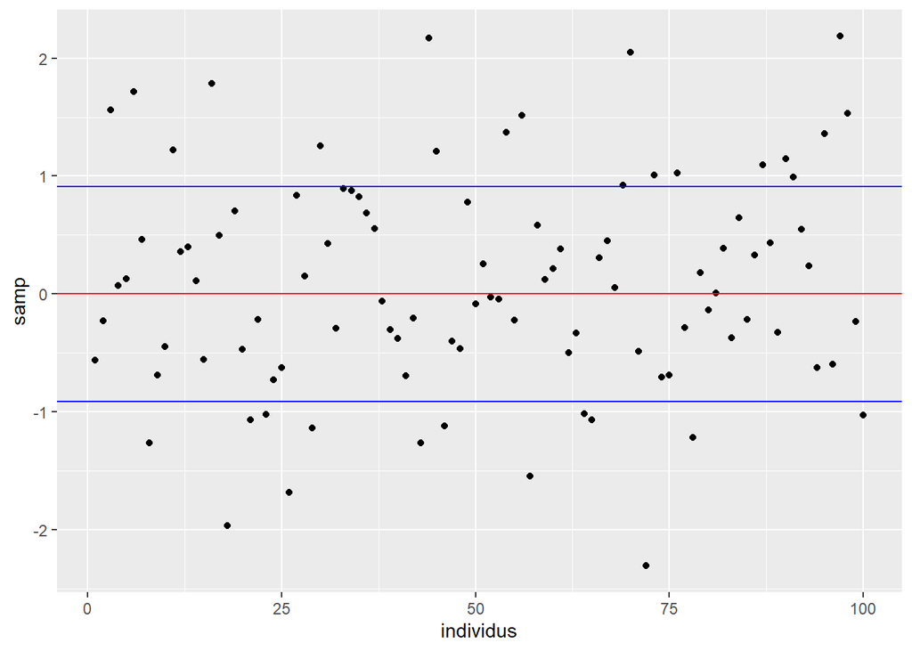

```r
# Scatter plot - graphique des points
data_sample %>%
        ggplot(. , aes(x = individus, y = samp)) +
        geom_point() +
        geom_hline(yintercept = 0, color = "red") +
        geom_hline(yintercept = 0 + sqrt(var(samp)), color = "blue") +
        geom_hline(yintercept = 0 - sqrt(var(samp)), color = "blue")
```

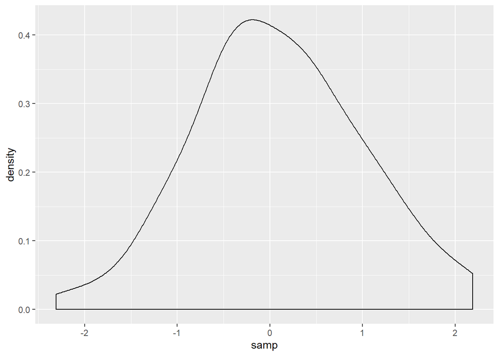

```r
# Densité
data_sample %>%
        ggplot(. ,aes(x = samp)) +
        geom_density()
```

```r
        # geom_histogram()

# Fonction de répartiton
# samp %>% tibble::as_tibble() %>%
#         mutate(cumfreq = samp)
#         ggplot(. ,aes( cumsum(order(samp)) ) ) +
#         geom_density()
```

## Fonctionnalités utiles pour effectuer des opérations de bases

Pour afficher les jeux de donnés disponibles :

```r
utils::data()
```

Récupérer le chemin vers le dossier de travail (get working directory) :

```r
getwd()
```

```
## [1] "C:/Users/cbonamy/Documents/Cours SUPINFO/3BAEX/day1"
```

Modifier le chemin vers le dossier de travail (set working directory) :

```r
setwd(dir = "some_path_to_working_directory")
```

Créer un dossier :

```r
dir.create(path = "data")
```

Ecrire un csv à partir d’un dataframe (ici `iris` est un jeu de donné présent dans R dans un des packages de base, on peut donc le charger directement) :

```r
write.csv(x = iris, file = "iris.csv")
```

Lire un csv selon un chemin donné (ici le csv se trouve dans le dossier de travail) puis examiner la structure des données chargées (str <-> structure) :

```r
nom_de_mon_dataframe <- read.csv(file = "iris.csv")
str(nom_de_mon_dataframe)
```

```
## 'data.frame':    150 obs. of  6 variables:
##  $ X           : int  1 2 3 4 5 6 7 8 9 10 ...
##  $ Sepal.Length: num  5.1 4.9 4.7 4.6 5 5.4 4.6 5 4.4 4.9 ...
##  $ Sepal.Width : num  3.5 3 3.2 3.1 3.6 3.9 3.4 3.4 2.9 3.1 ...
##  $ Petal.Length: num  1.4 1.4 1.3 1.5 1.4 1.7 1.4 1.5 1.4 1.5 ...
##  $ Petal.Width : num  0.2 0.2 0.2 0.2 0.2 0.4 0.3 0.2 0.2 0.1 ...
##  $ Species     : Factor w/ 3 levels "setosa","versicolor",..: 1 1 1 1 1 1 1 1 1 1 ...
```

## To Do pour compléter ce doc

- ajouter les formules R / Excel dans le tableau
- ajouter les formules et définition mathématiques des stats
- mentionner la fonctionnalité créer un projet (pour éviter les pb de `setwd`)